# F9_07_COMP_KONTR_ADDR_L1

Independent contractor street address line 1 · Code report

## Overview

**Description**

Highest compensated independent contractor (top 5 above 100K) foreign address line 1

**Table**

`F9-P07-T02-CONTRACTORS` (many)

**Location code**

`F990-PC-PART-07-SECTION-B-LINE-01-COL-A`, `F990-EZ-PART-06-LINE-51-COL-A`

**Family**

`F990-PC-PART-07-SECTION-B-LINE-01-COL-A` · siblings: F9_07_COMP_KONTR_ADDR_CITY, F9_07_COMP_KONTR_ADDR_CNTR, F9_07_COMP_KONTR_ADDR_L2, F9_07_COMP_KONTR_ADDR_STATE, F9_07_COMP_KONTR_ADDR_ZIP, F9_07_COMP_KONTR_NAME_ORG_L1

**Data type**

text (xsd: StreetAddressType, , CountryType)

**Scope**

PZ

**Status**

unreviewed

14

xpaths mapped (11 observed)

503,609

filings with a value

2009–2024

tax years observed

9

open flags (1 errors)

## Flags

| Severity | Flag | Xpath | Detail |
| --- | --- | --- | --- |
| ⚠ error | `COLLISION` | IRS990/ContractorCompensationGrp/ContractorAddress/ForeignAddress/AddressLine1Txt | 9515 filings contain 2+ of its xpaths; most common set: /Return/ReturnData/IRS990/ContractorCompensationGrp/ContractorAddress/ForeignAddress/AddressLine1Txt ; /Return/ReturnData/IRS990/ContractorCompe… |
| ⓘ info | `MANY_NOT_REPEATING` | IRS990EZ/CompensationOfHghstPdCntrctGrp/USAddress/AddressLine1Txt | many-to-one table, but 84% of values sit in no repeating element |
| ⓘ info | `MANY_NOT_REPEATING` | IRS990EZ/CompOfHghstPaidCntrctProfSer/AddressUS/AddressLine1 | many-to-one table, but 86% of values sit in no repeating element |
| ⓘ info | `MANY_NOT_REPEATING` | IRS990EZ/CompensationOfHghstPdCntrctGrp/USAddress/AddressLine1 | many-to-one table, but 88% of values sit in no repeating element |
| ⓘ info | `MANY_NOT_REPEATING` | IRS990EZ/CompensationOfHghstPdCntrctGrp/ForeignAddress/AddressLine1Txt | many-to-one table, but 86% of values sit in no repeating element |
| ⓘ info | `MANY_NOT_REPEATING` | IRS990EZ/CompOfHghstPaidCntrctProfSer/AddressForeign/AddressLine1 | many-to-one table, but 100% of values sit in no repeating element |
| ⓘ info | `UNOBSERVED` | IRS990/Form990PartVIISectionB/ContractorCompensation/AddressOfContractor/AddressForeign/AddressLine1 | never observed in TY2009-2024 filings |
| ⓘ info | `UNOBSERVED` | IRS990/Form990PartVIISectionB/ContractorCompensation/AddressOfContractor/AddressUS/AddressLine1 | never observed in TY2009-2024 filings |
| ⓘ info | `UNOBSERVED` | IRS990EZ/CompensationOfHghstPdCntrctGrp/ForeignAddress/AddressLine1 | never observed in TY2009-2024 filings |

## Xpaths

All mapped xpaths (under /Return/ReturnData or /Return/ReturnHeader), oldest first. Charts label each series by its xpath.

| Xpath | Form | Chart label | First year | Last year | Versions | Filings | Repeats in |
| --- | --- | --- | --- | --- | --- | --- | --- |
| IRS990/ContractorCompensation/AddressOfContractor/AddressUS/AddressLine1 | 990 | …orCompensation/AddressOfContractor/AddressUS/AddressLine1 | 2009 | 2012 | 18 | 77,556 | 65.2% |
| IRS990/ContractorCompensation/AddressOfContractor/AddressForeign/AddressLine1 | 990 | …pensation/AddressOfContractor/AddressForeign/AddressLine1 | 2009 | 2012 | 16 | 1,598 | 31.6% |
| IRS990EZ/CompOfHghstPaidCntrctProfSer/AddressUS/AddressLine1 | 990-EZ | same | 2009 | 2012 | 14 | 361 | 14.4% |
| IRS990EZ/CompOfHghstPaidCntrctProfSer/AddressForeign/AddressLine1 | 990-EZ | …/CompOfHghstPaidCntrctProfSer/AddressForeign/AddressLine1 | 2011 | 2011 | 1 | 2 | 0.0% |
| IRS990/ContractorCompensationGrp/ContractorAddress/USAddress/AddressLine1 | 990 | …rCompensationGrp/ContractorAddress/USAddress/AddressLine1 | 2013 | 2013 | 3 | 26,338 | 62.8% |
| IRS990/ContractorCompensationGrp/ContractorAddress/ForeignAddress/AddressLine1 | 990 | …ensationGrp/ContractorAddress/ForeignAddress/AddressLine1 | 2013 | 2013 | 3 | 591 | 33.2% |
| IRS990EZ/CompensationOfHghstPdCntrctGrp/USAddress/AddressLine1 | 990-EZ | …0EZ/CompensationOfHghstPdCntrctGrp/USAddress/AddressLine1 | 2013 | 2013 | 3 | 113 | 12.4% |
| IRS990/ContractorCompensationGrp/ContractorAddress/ForeignAddress/AddressLine1Txt | 990 | Other | 2014 | 2024 | 33 | 11,313 | 36.0% |
| IRS990/ContractorCompensationGrp/ContractorAddress/USAddress/AddressLine1Txt | 990 | Other | 2014 | 2024 | 34 | 383,412 | 62.9% |
| IRS990/Form990PartVIISectionB/ContractorCompensation/AddressOfContractor/AddressForeign/AddressLine1 | 990 | Other |  |  |  | 0 |  |
| IRS990/Form990PartVIISectionB/ContractorCompensation/AddressOfContractor/AddressUS/AddressLine1 | 990 | Other |  |  |  | 0 |  |
| IRS990EZ/CompensationOfHghstPdCntrctGrp/ForeignAddress/AddressLine1 | 990-EZ | Other |  |  |  | 0 |  |
| IRS990EZ/CompensationOfHghstPdCntrctGrp/ForeignAddress/AddressLine1Txt | 990-EZ | Other | 2015 | 2024 | 19 | 59 | 11.9% |
| IRS990EZ/CompensationOfHghstPdCntrctGrp/USAddress/AddressLine1Txt | 990-EZ | Other | 2014 | 2024 | 34 | 2,266 | 16.3% |

## Coverage

[figure not shown]

**Table view**

Table view: filings by tax year and series

| Tax year | …orCompensation/AddressOfContractor/AddressUS/AddressLine1 | …pensation/AddressOfContractor/AddressForeign/AddressLine1 | IRS990EZ/CompOfHghstPaidCntrctProfSer/AddressUS/AddressLine1 | …/CompOfHghstPaidCntrctProfSer/AddressForeign/AddressLine1 | …rCompensationGrp/ContractorAddress/USAddress/AddressLine1 | …ensationGrp/ContractorAddress/ForeignAddress/AddressLine1 | …0EZ/CompensationOfHghstPdCntrctGrp/USAddress/AddressLine1 | Other |
| --- | --- | --- | --- | --- | --- | --- | --- | --- |
| 2009 | 9,378 | 196 | 55 | 0 | 0 | 0 | 0 | 0 |
| 2010 | 20,146 | 421 | 84 | 0 | 0 | 0 | 0 | 0 |
| 2011 | 23,209 | 463 | 104 | 2 | 0 | 0 | 0 | 0 |
| 2012 | 24,823 | 518 | 118 | 0 | 0 | 0 | 0 | 0 |
| 2013 | 0 | 0 | 0 | 0 | 26,338 | 591 | 113 | 0 |
| 2014 | 0 | 0 | 0 | 0 | 0 | 0 | 0 | 29,027 |
| 2015 | 0 | 0 | 0 | 0 | 0 | 0 | 0 | 30,787 |
| 2016 | 0 | 0 | 0 | 0 | 0 | 0 | 0 | 32,088 |
| 2017 | 0 | 0 | 0 | 0 | 0 | 0 | 0 | 34,966 |
| 2018 | 0 | 0 | 0 | 0 | 0 | 0 | 0 | 35,425 |
| 2019 | 0 | 0 | 0 | 0 | 0 | 0 | 0 | 36,655 |
| 2020 | 0 | 0 | 0 | 0 | 0 | 0 | 0 | 38,393 |
| 2021 | 0 | 0 | 0 | 0 | 0 | 0 | 0 | 40,371 |
| 2022 | 0 | 0 | 0 | 0 | 0 | 0 | 0 | 43,260 |
| 2023 | 0 | 0 | 0 | 0 | 0 | 0 | 0 | 45,198 |
| 2024 | 0 | 0 | 0 | 0 | 0 | 0 | 0 | 30,880 |

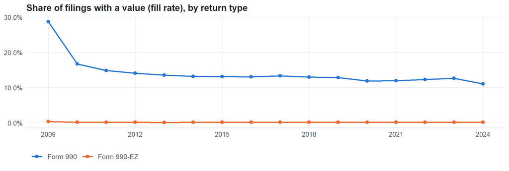

**Table view**

Table view: fill rate

| Tax year | Return type | Filings | All filings | Fill rate |
| --- | --- | --- | --- | --- |
| 2009 | Form 990 | 9,574 | 33,311 | 28.74% |
| 2009 | Form 990-EZ | 55 | 15,470 | 0.36% |
| 2010 | Form 990 | 20,567 | 123,025 | 16.72% |
| 2010 | Form 990-EZ | 84 | 63,326 | 0.13% |
| 2011 | Form 990 | 23,672 | 159,504 | 14.84% |
| 2011 | Form 990-EZ | 106 | 82,048 | 0.13% |
| 2012 | Form 990 | 25,341 | 179,688 | 14.10% |
| 2012 | Form 990-EZ | 118 | 93,750 | 0.13% |
| 2013 | Form 990 | 26,929 | 198,855 | 13.54% |
| 2013 | Form 990-EZ | 113 | 104,375 | 0.11% |
| 2014 | Form 990 | 28,898 | 218,619 | 13.22% |
| 2014 | Form 990-EZ | 129 | 116,417 | 0.11% |
| 2015 | Form 990 | 30,642 | 233,519 | 13.12% |
| 2015 | Form 990-EZ | 145 | 124,894 | 0.12% |
| 2016 | Form 990 | 31,919 | 243,903 | 13.09% |
| 2016 | Form 990-EZ | 169 | 130,484 | 0.13% |
| 2017 | Form 990 | 34,799 | 261,612 | 13.30% |
| 2017 | Form 990-EZ | 167 | 139,144 | 0.12% |
| 2018 | Form 990 | 35,252 | 271,442 | 12.99% |
| 2018 | Form 990-EZ | 173 | 149,384 | 0.12% |
| 2019 | Form 990 | 36,451 | 283,694 | 12.85% |
| 2019 | Form 990-EZ | 204 | 152,622 | 0.13% |
| 2020 | Form 990 | 38,166 | 320,342 | 11.91% |
| 2020 | Form 990-EZ | 227 | 169,864 | 0.13% |
| 2021 | Form 990 | 40,097 | 336,480 | 11.92% |
| 2021 | Form 990-EZ | 272 | 202,724 | 0.13% |
| 2022 | Form 990 | 42,957 | 349,055 | 12.31% |
| 2022 | Form 990-EZ | 303 | 206,130 | 0.15% |
| 2023 | Form 990 | 44,912 | 354,768 | 12.66% |
| 2023 | Form 990-EZ | 286 | 206,379 | 0.14% |
| 2024 | Form 990 | 30,630 | 277,298 | 11.05% |
| 2024 | Form 990-EZ | 250 | 178,867 | 0.14% |

## Repeating groups

Table cardinality in the concordance: **many**. 10 of 11 observed xpaths repeat within a filing.

Repeating element each xpath was observed in (from the raw indexed xpath)

| Xpath | Repeating element | Filings (summed over years) |
| --- | --- | --- |
| IRS990/ContractorCompensation/AddressOfContractor/AddressForeign/AddressLine1 | (none) | 249 |
| IRS990/ContractorCompensation/AddressOfContractor/AddressForeign/AddressLine1 | IRS990/ContractorCompensation | 1349 |
| IRS990/ContractorCompensation/AddressOfContractor/AddressUS/AddressLine1 | (none) | 26671 |
| IRS990/ContractorCompensation/AddressOfContractor/AddressUS/AddressLine1 | IRS990/ContractorCompensation | 50885 |
| IRS990EZ/CompOfHghstPaidCntrctProfSer/AddressUS/AddressLine1 | (none) | 309 |
| IRS990EZ/CompOfHghstPaidCntrctProfSer/AddressUS/AddressLine1 | IRS990EZ/CompOfHghstPaidCntrctProfSer | 52 |
| IRS990EZ/CompOfHghstPaidCntrctProfSer/AddressForeign/AddressLine1 | (none) | 2 |
| IRS990/ContractorCompensationGrp/ContractorAddress/ForeignAddress/AddressLine1 | (none) | 88 |
| IRS990/ContractorCompensationGrp/ContractorAddress/ForeignAddress/AddressLine1 | IRS990/ContractorCompensationGrp | 503 |
| IRS990/ContractorCompensationGrp/ContractorAddress/USAddress/AddressLine1 | (none) | 9683 |
| IRS990/ContractorCompensationGrp/ContractorAddress/USAddress/AddressLine1 | IRS990/ContractorCompensationGrp | 16655 |
| IRS990EZ/CompensationOfHghstPdCntrctGrp/USAddress/AddressLine1 | (none) | 99 |
| IRS990EZ/CompensationOfHghstPdCntrctGrp/USAddress/AddressLine1 | IRS990EZ/CompensationOfHghstPdCntrctGrp | 14 |
| IRS990/ContractorCompensationGrp/ContractorAddress/ForeignAddress/AddressLine1Txt | (none) | 1857 |
| IRS990/ContractorCompensationGrp/ContractorAddress/ForeignAddress/AddressLine1Txt | IRS990/ContractorCompensationGrp | 9456 |
| IRS990/ContractorCompensationGrp/ContractorAddress/USAddress/AddressLine1Txt | (none) | 140318 |
| IRS990/ContractorCompensationGrp/ContractorAddress/USAddress/AddressLine1Txt | IRS990/ContractorCompensationGrp | 243094 |
| IRS990EZ/CompensationOfHghstPdCntrctGrp/USAddress/AddressLine1Txt | (none) | 1894 |
| IRS990EZ/CompensationOfHghstPdCntrctGrp/USAddress/AddressLine1Txt | IRS990EZ/CompensationOfHghstPdCntrctGrp | 372 |
| IRS990EZ/CompensationOfHghstPdCntrctGrp/ForeignAddress/AddressLine1Txt | (none) | 51 |
| IRS990EZ/CompensationOfHghstPdCntrctGrp/ForeignAddress/AddressLine1Txt | IRS990EZ/CompensationOfHghstPdCntrctGrp | 8 |

## Values

| Result | Check | Detail |
| --- | --- | --- |
| ▲ warn | Small code list | up to 81772 distinct values per xpath and year |
| ▲ warn | Codes share one format | 37% have the shape AA AAA 999999 |
| ✓ pass | Consistent letter case | 0.1% of values are lower case |

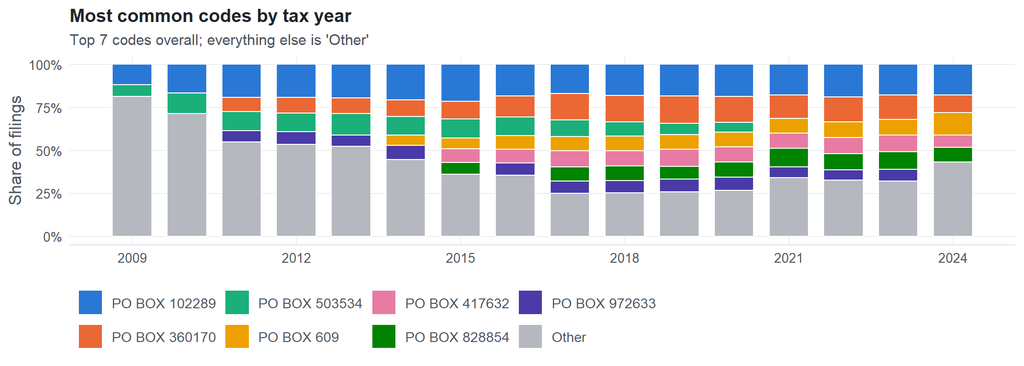

**Table view**

Table view: filings by code and tax year

| tax_year | PO BOX 102289 | PO BOX 360170 | PO BOX 503534 | PO BOX 609 | PO BOX 417632 | PO BOX 828854 | PO BOX 972633 | Other |
| --- | --- | --- | --- | --- | --- | --- | --- | --- |
| 2009 | 34 | 0 | 20 | 0 | 0 | 0 | 0 | 233 |
| 2010 | 100 | 0 | 70 | 0 | 0 | 0 | 0 | 424 |
| 2011 | 122 | 52 | 72 | 0 | 0 | 0 | 40 | 349 |
| 2012 | 138 | 66 | 79 | 0 | 0 | 0 | 53 | 385 |
| 2013 | 142 | 65 | 92 | 0 | 0 | 0 | 48 | 379 |
| 2014 | 162 | 76 | 86 | 45 | 0 | 0 | 66 | 350 |
| 2015 | 164 | 76 | 85 | 47 | 60 | 51 | 0 | 274 |
| 2016 | 126 | 86 | 74 | 54 | 56 | 0 | 48 | 245 |
| 2017 | 161 | 147 | 91 | 79 | 89 | 79 | 67 | 237 |
| 2018 | 175 | 150 | 81 | 81 | 87 | 83 | 69 | 245 |
| 2019 | 181 | 156 | 65 | 81 | 98 | 73 | 74 | 252 |
| 2020 | 190 | 156 | 57 | 87 | 90 | 90 | 79 | 272 |
| 2021 | 193 | 147 | 0 | 92 | 96 | 118 | 67 | 370 |
| 2022 | 219 | 165 | 0 | 106 | 105 | 109 | 70 | 373 |
| 2023 | 194 | 157 | 0 | 99 | 105 | 112 | 75 | 350 |
| 2024 | 121 | 70 | 0 | 91 | 48 | 58 | 0 | 295 |

Code frequencies (all xpaths, all years)

| Code | Filings | Share |
| --- | --- | --- |
| PO BOX 102289 | 2,422 | 18.5% |
| PO BOX 360170 | 1,569 | 12.0% |
| PO BOX 503534 | 872 | 6.6% |
| PO BOX 609 | 862 | 6.6% |
| PO BOX 417632 | 834 | 6.4% |
| PO BOX 828854 | 773 | 5.9% |
| PO BOX 972633 | 756 | 5.8% |
| PO BOX 12140 | 698 | 5.3% |
| PO BOX 536922 | 624 | 4.8% |
| PO BOX 972651 | 583 | 4.4% |
| PO BOX 71985 | 445 | 3.4% |
| 4880 PAYSPHERE CIRCLE | 380 | 2.9% |
| PO BOX 8103 | 245 | 1.9% |
| PO BOX 91337 | 214 | 1.6% |
| PO BOX 847950 | 188 | 1.4% |
| PO BOX 850737 | 131 | 1.0% |
| PO Box 102289 | 108 | 0.8% |
| PO BOX 809056 | 95 | 0.7% |
| PO BOX 98347 | 93 | 0.7% |
| NONE | 82 | 0.6% |
| PO BOX 9146 | 60 | 0.5% |
| PO BOX 650036 | 58 | 0.4% |
| PO BOX 934057 | 56 | 0.4% |
| PO BOX 405547 | 52 | 0.4% |
| 560 CARILLON PARKWAY | 49 | 0.4% |
| 5155 PAYSPHERE CIRCLE | 42 | 0.3% |
| PO BOX 734596 | 42 | 0.3% |
| 1101 MARKET STREET | 40 | 0.3% |
| N/A | 36 | 0.3% |
| PO Box 536922 | 23 | 0.2% |

First rows shown.

## Examples

| Tax year | Return | Xpath | Organization | Value | Source |
| --- | --- | --- | --- | --- | --- |
| 2024 | 990 | IRS990/ContractorCompensationGrp/ContractorAddress/ForeignAddress/AddressLine1Txt | Open Path Psychotherapy Collective | Formansgrand 13 | [XML](https://gt990datalake-rawdata.s3.amazonaws.com/EfileData/XmlFiles/202522049349300527_public.xml) |
| 2024 | 990 | IRS990/ContractorCompensationGrp/ContractorAddress/USAddress/AddressLine1Txt | YMCA OF THE FOOTHILLS | 8025 REDLANDS STREET | [XML](https://gt990datalake-rawdata.s3.amazonaws.com/EfileData/XmlFiles/202532059349301333_public.xml) |
| 2024 | 990EZ | IRS990EZ/CompensationOfHghstPdCntrctGrp/ForeignAddress/AddressLine1Txt | ARAB FORUM FOR THE RIGHTS OF PERSONS | Hay Chmaou Alykot -Imn 24-apt1 | [XML](https://gt990datalake-rawdata.s3.amazonaws.com/EfileData/XmlFiles/202511489349200636_public.xml) |
| 2024 | 990EZ | IRS990EZ/CompensationOfHghstPdCntrctGrp/USAddress/AddressLine1Txt | FRIENDS OF NORD INC | 935 GRAVIER ST STE 800 | [XML](https://gt990datalake-rawdata.s3.amazonaws.com/EfileData/XmlFiles/202501649349200810_public.xml) |
| 2023 | 990 | IRS990/ContractorCompensationGrp/ContractorAddress/ForeignAddress/AddressLine1Txt | FOREST TRENDS ASSOCIATION | AVE ANTONIO MIROQUESADA 425 OF 401 | [XML](https://gt990datalake-rawdata.s3.amazonaws.com/EfileData/XmlFiles/202421499349300997_public.xml) |
| 2023 | 990 | IRS990/ContractorCompensationGrp/ContractorAddress/USAddress/AddressLine1Txt | ZEPF CENTER | 25661 FT MEIGS RD STE E | [XML](https://gt990datalake-rawdata.s3.amazonaws.com/EfileData/XmlFiles/202423399349300887_public.xml) |
| 2023 | 990EZ | IRS990EZ/CompensationOfHghstPdCntrctGrp/ForeignAddress/AddressLine1Txt | CHINA KINGDOM RESOURCES | Jinfang No 1 Courtyard | [XML](https://gt990datalake-rawdata.s3.amazonaws.com/EfileData/XmlFiles/202413209349203206_public.xml) |
| 2023 | 990EZ | IRS990EZ/CompensationOfHghstPdCntrctGrp/USAddress/AddressLine1Txt | 7 Oaks Healthcare Inc | 123 South Calhoun St | [XML](https://gt990datalake-rawdata.s3.amazonaws.com/EfileData/XmlFiles/202521819349200837_public.xml) |
| 2022 | 990 | IRS990/ContractorCompensationGrp/ContractorAddress/ForeignAddress/AddressLine1Txt | CODEORG | COSTA BRAVA 22 DH 2 A | [XML](https://gt990datalake-rawdata.s3.amazonaws.com/EfileData/XmlFiles/202313199349312426_public.xml) |
| 2022 | 990 | IRS990/ContractorCompensationGrp/ContractorAddress/USAddress/AddressLine1Txt | CANTERBURY TOWER INC | 1720 W CASS STREET | [XML](https://gt990datalake-rawdata.s3.amazonaws.com/EfileData/XmlFiles/202332979349301963_public.xml) |
| 2022 | 990EZ | IRS990EZ/CompensationOfHghstPdCntrctGrp/ForeignAddress/AddressLine1Txt | RICE INSTITUTE INC | F-3055 RAJAJIPURAM | [XML](https://gt990datalake-rawdata.s3.amazonaws.com/EfileData/XmlFiles/202331989349201718_public.xml) |
| 2022 | 990EZ | IRS990EZ/CompensationOfHghstPdCntrctGrp/USAddress/AddressLine1Txt | HOUSE OF REDEMPTION | 3387 East 75th Street | [XML](https://gt990datalake-rawdata.s3.amazonaws.com/EfileData/XmlFiles/202321049349200612_public.xml) |

## Reviewer checklist

- The definition matches the form line and instructions for every xpath’s schema years.
- Every xpath pooled here measures the same thing on the 990 and 990-EZ (close enough for analysis).
- The coverage chart has no unexplained gaps or jumps between tax years.
- Each open flag is fixed, or accepted with a note in validation_log.csv.
- Every code is valid for the list the form uses (state, country, valuation method, …).
- The code list and its meaning did not change across schema versions.
- Codes are stored as text, so values like leading zeros are preserved.

Record the review as a row in `inst/extdata/src/validation_log.csv` (variable_name, reviewer, date, status, note). Evidence built 2026-09-23 17:09:04 MST from the ef2 DuckDB builds (tax years 2009–2024).